# Human Activity Recognition

Sangjin Park

2015년 11월 21일

# Practice Machine Learning

The training data for this project are available here: https://d396qusza40orc.cloudfront.net/predmachlearn/pml-training.csv

The test data are available here: https://d396qusza40orc.cloudfront.net/predmachlearn/pml-testing.csv

The data for this project come from this source: http://groupware.les.inf.puc-rio.br/har.

# Load the data

load the data and make NA for NA, #DIV/0!, “”.

```r
datarow <- read.csv(file = "pml-training.csv", na.strings=c("NA","#DIV/0!",""))
datatest <- read.csv(file = "pml-testing.csv",na.strings=c("NA","#DIV/0!",""))
```

# Clean the data

remove the columns of NAs.

```r
data <- datarow[,colSums(is.na(datarow)) == 0]
test <- datatest[,colSums(is.na(datatest)) == 0]
names(data)
```

```
##  [1] "X"                    "user_name"            "raw_timestamp_part_1"
##  [4] "raw_timestamp_part_2" "cvtd_timestamp"       "new_window"
##  [7] "num_window"           "roll_belt"            "pitch_belt"
## [10] "yaw_belt"             "total_accel_belt"     "gyros_belt_x"
## [13] "gyros_belt_y"         "gyros_belt_z"         "accel_belt_x"
## [16] "accel_belt_y"         "accel_belt_z"         "magnet_belt_x"
## [19] "magnet_belt_y"        "magnet_belt_z"        "roll_arm"
## [22] "pitch_arm"            "yaw_arm"              "total_accel_arm"
## [25] "gyros_arm_x"          "gyros_arm_y"          "gyros_arm_z"
## [28] "accel_arm_x"          "accel_arm_y"          "accel_arm_z"
## [31] "magnet_arm_x"         "magnet_arm_y"         "magnet_arm_z"
## [34] "roll_dumbbell"        "pitch_dumbbell"       "yaw_dumbbell"
## [37] "total_accel_dumbbell" "gyros_dumbbell_x"     "gyros_dumbbell_y"
## [40] "gyros_dumbbell_z"     "accel_dumbbell_x"     "accel_dumbbell_y"
## [43] "accel_dumbbell_z"     "magnet_dumbbell_x"    "magnet_dumbbell_y"
## [46] "magnet_dumbbell_z"    "roll_forearm"         "pitch_forearm"
## [49] "yaw_forearm"          "total_accel_forearm"  "gyros_forearm_x"
## [52] "gyros_forearm_y"      "gyros_forearm_z"      "accel_forearm_x"
## [55] "accel_forearm_y"      "accel_forearm_z"      "magnet_forearm_x"
## [58] "magnet_forearm_y"     "magnet_forearm_z"     "classe"
```

remove variables which isn’t necessity for predicting the model.

```r
data <- data[,-(1:7)]
test <- test[,-(1:7)]
```

So, I have 53 variables for fitting the model.

# Creating Training and Validation data sets

```r
library(caret)
set.seed(333)  ## set.seed for reproducibility
inTrain <- createDataPartition(y=data$classe, p=0.7, list=FALSE)
training <- data[inTrain,] ; validation <- data[-inTrain,]
dim(training)
```

```
## [1] 13737    53
```

```r
dim(validation)
```

```
## [1] 5885   53
```

# Build model

Predicting with Tree

```r
modtree <- train(classe ~ ., method = "rpart", data=training)
print(modtree$finalModel)
```

```
## n= 13737
##
## node), split, n, loss, yval, (yprob)
##       * denotes terminal node
##
##  1) root 13737 9831 A (0.28 0.19 0.17 0.16 0.18)
##    2) roll_belt< 130.5 12573 8677 A (0.31 0.21 0.19 0.18 0.11)
##      4) pitch_forearm< -33.95 1113    8 A (0.99 0.0072 0 0 0) *
##      5) pitch_forearm>=-33.95 11460 8669 A (0.24 0.23 0.21 0.2 0.12)
##       10) magnet_dumbbell_y< 436.5 9640 6917 A (0.28 0.18 0.24 0.19 0.11)
##         20) roll_forearm< 123.5 6011 3571 A (0.41 0.18 0.18 0.17 0.062) *
##         21) roll_forearm>=123.5 3629 2407 C (0.078 0.17 0.34 0.23 0.18) *
##       11) magnet_dumbbell_y>=436.5 1820  894 B (0.037 0.51 0.042 0.23 0.19) *
##    3) roll_belt>=130.5 1164   10 E (0.0086 0 0 0 0.99) *
```

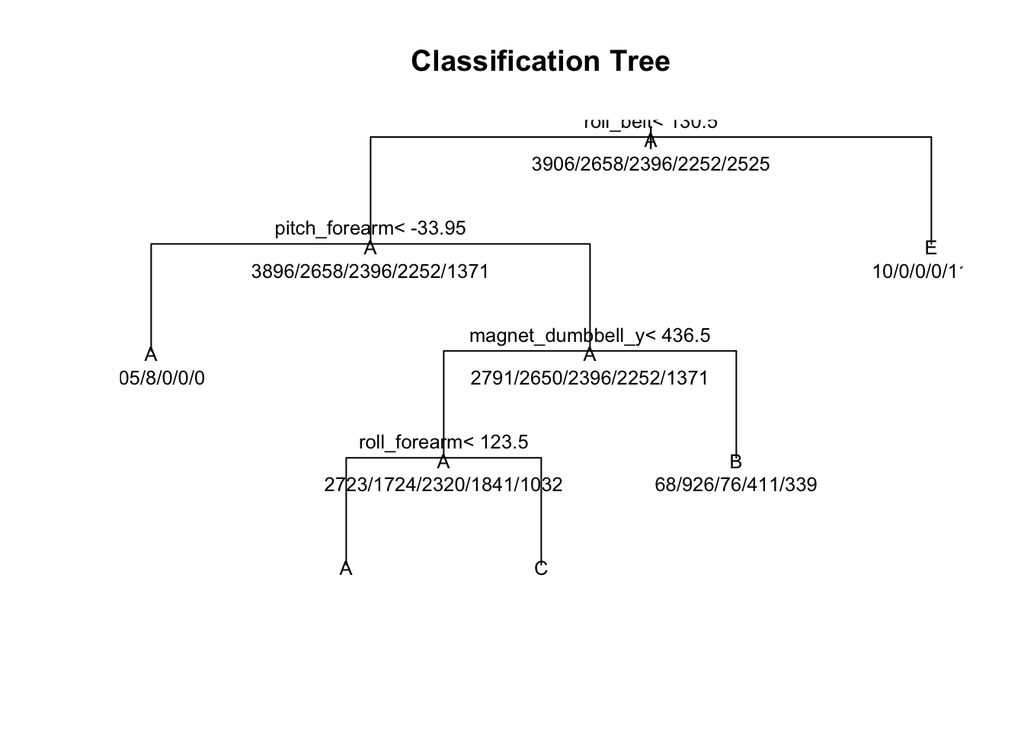

```r
plot(modtree$finalModel, uniform = TRUE, main = "Classification Tree")
text(modtree$finalModel, use.n = TRUE, all = TRUE, cex=.8 )
```

```r
library(rattle)
```

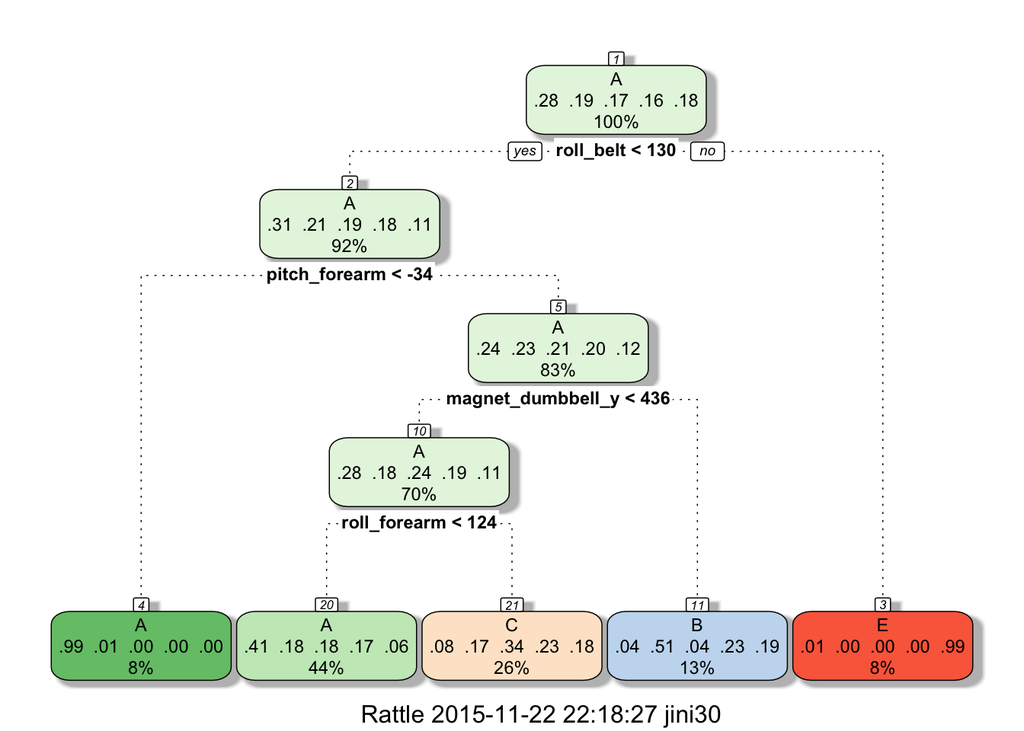

```r
fancyRpartPlot(modtree$finalModel)
```

I can see important variables by predicting with tree as order by roll_belt, pitch_forearm, magnet_dumbbell_y, roll_forearm.

# Random Forest

```r
modrf <- train(classe ~ ., method = "rf",
               data=training, trControl = trainControl(method = "cv"), number=5)
modrf$finalModel
```

```
##
## Call:
##  randomForest(x = x, y = y, mtry = param$mtry, number = 5)
##                Type of random forest: classification
##                      Number of trees: 500
## No. of variables tried at each split: 2
##
##         OOB estimate of  error rate: 0.68%
## Confusion matrix:
##      A    B    C    D    E  class.error
## A 3905    1    0    0    0 0.0002560164
## B   11 2634   13    0    0 0.0090293454
## C    0   20 2373    3    0 0.0095993322
## D    0    0   37 2213    2 0.0173179396
## E    0    0    2    5 2518 0.0027722772
```

The modrf model has an estimate the OOB(overall out-of-bag) error rate of 0.68%. It is qulite good.

# Validate Performance

```r
prerf <- predict(modrf, validation)
confusionMatrix(validation$classe, prerf)
```

```
## Confusion Matrix and Statistics
##
##           Reference
## Prediction    A    B    C    D    E
##          A 1674    0    0    0    0
##          B    4 1135    0    0    0
##          C    0    6 1018    2    0
##          D    0    0   16  948    0
##          E    0    0    0    5 1077
##
## Overall Statistics
##
##                Accuracy : 0.9944
##                  95% CI : (0.9921, 0.9961)
##     No Information Rate : 0.2851
##     P-Value [Acc > NIR] : < 2.2e-16
##
##                   Kappa : 0.9929
##  Mcnemar's Test P-Value : NA
##
## Statistics by Class:
##
##                      Class: A Class: B Class: C Class: D Class: E
## Sensitivity            0.9976   0.9947   0.9845   0.9927   1.0000
## Specificity            1.0000   0.9992   0.9984   0.9968   0.9990
## Pos Pred Value         1.0000   0.9965   0.9922   0.9834   0.9954
## Neg Pred Value         0.9991   0.9987   0.9967   0.9986   1.0000
## Prevalence             0.2851   0.1939   0.1757   0.1623   0.1830
## Detection Rate         0.2845   0.1929   0.1730   0.1611   0.1830
## Detection Prevalence   0.2845   0.1935   0.1743   0.1638   0.1839
## Balanced Accuracy      0.9988   0.9969   0.9914   0.9947   0.9995
```

# Predict test data set

```r
pretest <- predict(modrf, test)
pretest
```

```
##  [1] B A B A A E D B A A B C B A E E A B B B
## Levels: A B C D E
```

The 20 samples from the test datasets are classified.

# Submission

```r
pml_write_files = function(x){
  n = length(x)
  for(i in 1:n){
    filename = paste0("problem_id_",i,".txt")
    write.table(x[i],file=filename,quote=FALSE,row.names=FALSE,col.names=FALSE)
  }
}

pml_write_files(pretest)
```